# 10: Data Scraping

Environmental Data Analytics | John Fay

Spring 2021

## Objectives

1. Acquire and scrape data from web sources
2. Process web-scraped data into reproducible formats
3. Use wrangling techniques to automate scraping processes

## Set up

```r
getwd()
```

```
## [1] "/Users/evamay/Desktop/ENV872/Environmental.Data.Analytics.2021/Lessons"
```

```r
#remotes::install_github("r-spatial/mapview")
library(mapview)
library(tidyverse)
library(lubridate)
library(ggplot2)
#install.packages("rvest")
library(rvest)
library(dplyr)

# Set theme
mytheme <- theme_classic() +
  theme(axis.text = element_text(color = "black"),
        legend.position = "top")
theme_set(mytheme)
```

# Part 1. Scraping data

## What does it mean to “scrape data” from the web?

The internet is a **vast** source of data. Often websites will share links to download data directly. And more and more organizations are providing application programming interfaces or APIs that allow you to tap in to on-line datasets programmatically. Still, some data that may be useful to you might appear on a website, but the website doesn’t offer an easy way of grabbing it into your coding environment. It’s this last example where scraping comes in handy.

Web scraping is the process of pulling data directly from websites. Copy and paste is a brute force form of web scraping, but one that often also involves a lot of clean up of your data. A slightly more elegant, yet still nimble approach is to navigate the code in which the web page was written and perhaps glean the data you want from there. This doesn’t always work, and it still takes some trial and error, but it can give you access to invaluable datasets in a pinch.

### Some important caveats

You might now feel that web scraping isn’t always legitimate - and you’re right! Not all content providers want their sites to be scraped. To ensure that your web scraping is done ethically, check out this great article covering the ethics and legality of web scraping: https://prowebscraper.com/blog/is-web-scraping-legal/

> For discussion: Can you give examples of ethical and unethical web scraping?

## 1.1 Exploring the data we want to scrape

- Navigate to https://www.ncwater.org/WUDC/app/WWATR/report. This site lists water use reports submitted by various industries around NC.
- Click on the link to view the report for “Plant 15” facility in 2020: https://www.ncwater.org/WUDC/app/WWATR/report/view/0004-0001/2020
- View the data we can scrape on this page.

What we want to do first is scrape the average daily water withdrawal for a given site along with the site’s “registrant” and their “facility type”. Once we see how it’s done with one site, we’ll look at how we can iterate through many sites and grab the data we want data from each.

## 1.2 Fetching the contents

To begin, we’ll fetch the contents of the web site into our coding environment using RVest’s `read_html()` function.

```r
#Fetch the web resources from the URL
webpage <- read_html('https://www.ncwater.org/WUDC/app/WWATR/report/view/0004-0001/2020')
webpage
```

```
## {html_document}
## <html xmlns="http://www.w3.org/1999/xhtml">
## [1] <head>\n<title>DWR :: Water Withdrawal and Transfer Registration</title>\ ...
## [2] <body>\r\n\r\n    <div id="header">\r\n    <h1 id="site-title">\n<span>NC ...
```

```r
#data on website is water use reports, water withdrawals and transfers
#telling R go to a website and go to its contents
#this page is a set of nodes and a set of documents
```

## 1.3 Scraping the data

Now we want to scrape some data shown in the page into our R coding environment. The bits we want to scrape are: * The name of the Registrant: “American & Efird, Inc.” * The name of the facility: “Plant 15” * The facility type: “Industrial” * And the average water withdrawals for each month: “0.584. 0.647, 0.543, etc.”

To do this we first need to install a tool on our web browser to be able to call the web text we need. The tool is called a Selector Gadget, which for Chrome can be found [here](https://chrome.google.com/webstore/detail/selectorgadget/mhjhnkcfbdhnjickkkdbjoemdmbfginb?hl=en).

The selector gadget tool is useful in identifying the internal ids of the elements shown in the web page that we want to extract. Using it is a bit clumsy, often requiring a bit of mucking about, but it still makes our work a lot easier. We’ll begin by using it to determine the id of the box containing the registrant of our our site. 1. Activate the Selector Gadget tool. 2. Click on the box listing the registrant (“American & Efird, Inc.”). You’ll see a number of boxes in yellow, but we just want the one box in yellow. 3. Click various other boxes until only the one we want is highlighted in yellow (or green). It’s ok if others are in red. This may take a bit of trial and error, and if you get too mess up, you can start over by clicking the `Clear` button in the Selector Gadget floating toolbar.

When successful, the box should display `.table tr:nth-child(1) td:nth-child(2)`. This uniquely identifies the html element containing the data we want. #.table tr:nth-child(1) td:nth-child(2)

With this id known, we can extract its value in a two-step process. First we use `html_nodes()` to grab the element using its tag. Then we extract the value associated with that element text using the `html_text()` function.

```r
#new variable that's extracted from the webpage via the nodes that include the tag we got from the selector tool:
the_registrant <- webpage %>%
  html_nodes(".table tr:nth-child(1) td:nth-child(2)") %>%
  html_text()
the_registrant
```

```
## [1] "American & Efird, Inc."
```

EXERCISE: In the code chunk below, see if you can extract the Facility Name and Facility Type from the web page.

```r
the_facility_name <- webpage %>%
  html_nodes("tr:nth-child(2) th+ .left:nth-child(2)") %>%
  html_text()
the_facility_name
```

```
## [1] "Plant 15"
```

```r
the_facility_type <- webpage %>%
  html_nodes("tr:nth-child(2) .left~ .left+ td.left") %>%
  html_text()
the_facility_type
```

```
## [1] "Industrial"
```

Below is the code to extract average daily withdrawls. Add your code to extract max daily withdrawals into the `max_withdrawals` variable.

```r
#can select multiple items by keeping more than 1 thing highlighted on the webpage with the gadget tool
avg_withdrawals <- webpage %>%
  html_nodes('.table:nth-child(7) td:nth-child(7) , .table:nth-child(7) td:nth-child(3)') %>%
  html_text()
avg_withdrawals
```

```
##  [1] ".584" ".492" ".647" ".613" ".543" ".683" ".371" ".650" ".349" ".535"
## [11] ".447" ".449"
```

```r
max_withdrawals <- webpage %>%
  html_nodes('.table:nth-child(7) td:nth-child(8) , .table:nth-child(7) td:nth-child(4)') %>%
  html_text()
max_withdrawals
```

```
##  [1] "1.029" "1.045" "1.056" "1.115" ".934"  "1.096" ".978"  "1.018" "1.146"
## [10] "1.046" "1.111" ".889"
```

## 1.4 Construct a dataframe from the data & plot the values

Now that we’ve scraped the data we want into our coding environment, the next step is to wrangle these data into formats we can work with more easily, i.e. a dataframe. Here, we emply the techniques we’ve learned earlier in this class to do this and then plot the data.

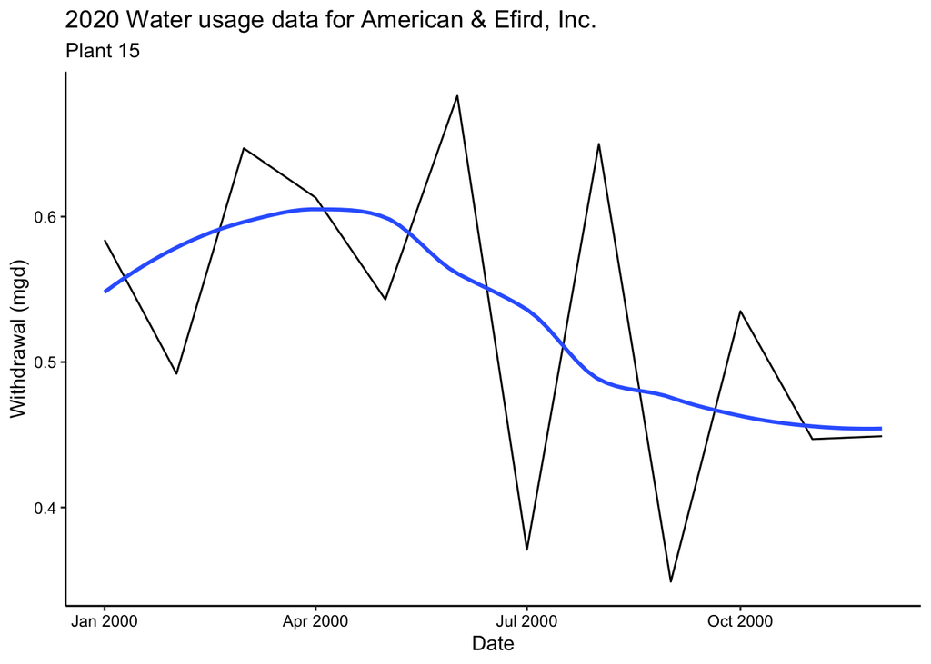

```r
#once we have data, use wrangling skills to make a df
#Create a dataframe of withdrawals
df_withdrawals <- data.frame("Month" = rep(1:12),#list 1-12
                             "Year" = rep(2000,12), #repeat 2000 12x
                             "Avg_Withdrawals_mgd" = as.numeric(avg_withdrawals),#change from chr to num
                             "Max_Withdrawals_mgd" = as.numeric(max_withdrawals))

#Modify the dataframe to include the facility name and type as well as the date (as date object)
df_withdrawals <- df_withdrawals %>%
  mutate(Registrant = !!the_registrant,
         Facility_name = !!the_facility_name,
         Facility_type = !!the_facility_type,
         Date = my(paste(Month,"-",Year)))
#!! = "bang" = "don't set it to this as a string, set it to the variable named this"
#Plot
ggplot(df_withdrawals,aes(x=Date,y=Avg_Withdrawals_mgd)) +
  geom_line() +
  geom_smooth(method="loess",se=FALSE) +
  labs(title = paste("2020 Water usage data for",the_registrant),
       subtitle = the_facility_name,
       y="Withdrawal (mgd)",
       x="Date")
```

```r
#plot shows our scraped data (in black, a line plot) and an interpolated trend line (loess)
```

# Part 2. Automating the scraping process

## 2.1 Streamline the process

Data! But let’s keep going. Next, we’ll streamline what we’ve learned above in an effort to automate the process.

This begins by setting the parameters of the page we’ll be scraping to variables so we can more easily point to, say, a different facility or a different year. Then we update our other code to use these parameters to scrape the data.

```r
#breaking URL into components
#paste0 eliminates adding a space bw elements
#Construct the scraping web address, i.e. its URL
the_base_url <- 'https://www.ncwater.org/WUDC/app/WWATR/report/view'
the_facility <- '0004-0001'
the_year <- 2015
the_scrape_url <- paste0(the_base_url, '/', the_facility, '/', the_year)
print(the_scrape_url)
```

```
## [1] "https://www.ncwater.org/WUDC/app/WWATR/report/view/0004-0001/2015"
```

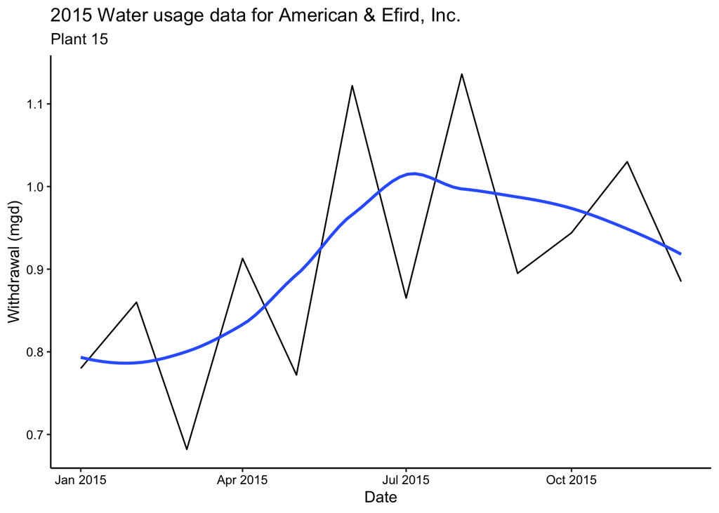

```r
#so now we've built the site by pasting its components together

#Retrieve the website contents to create a hook into the website:
the_website <- read_html(the_scrape_url)

#Set the element address variables (determined in the previous step) [converting input tags into variables]
the_registrant_tag <- '.table tr:nth-child(1) td:nth-child(2)'
the_facility_name_tag <- 'tr:nth-child(2) th+ .left:nth-child(2)'
the_facility_id_tag <- 'tr:nth-child(2) .left~ .left+ td.left'
the_data_tag <- '.table:nth-child(7) td:nth-child(7) , .table:nth-child(7) td:nth-child(3)'

#Scrape the data items
the_registrant <- the_website %>% html_nodes(the_registrant_tag) %>% html_text()
the_facility_name <- the_website %>%   html_nodes(the_facility_name_tag) %>%  html_text()
the_facility_type <- the_website %>% html_nodes(the_facility_id_tag) %>% html_text()
the_withdrawals <- the_website %>% html_nodes(the_data_tag) %>% html_text()

#Construct a dataframe from the scraped data
df_withdrawals <- data.frame("Month" = rep(1:12),
                             "Year" = rep(the_year,12),
                             "Avg_Withdrawals_mgd" = as.numeric(the_withdrawals)) %>%
  mutate(Registrant = !!the_registrant,
         Facility_name = !!the_facility_name,
         Facility_type = !!the_facility_type,
         Date = my(paste(Month,"-",Year)))

#Plot
ggplot(df_withdrawals,aes(x=Date,y=Avg_Withdrawals_mgd)) +
  geom_line() +
  geom_smooth(method="loess",se=FALSE) +
  labs(title = paste(the_year,"Water usage data for",the_registrant),
       subtitle = the_facility_name,
       y="Withdrawal (mgd)",
       x="Date")
```

```r
#instead of overriding above code to create a new df for each site/year, what if we want to build on existing df?
```

## 2.2 Automation, Step 1: Build a function

We have our code so we can fairly easily scrape any site (if we know its ID) for any year. Let’s improve our code so we can automate the process more easily and perhaps scrape many years worth of data. To make this process run more easily, we’ll first convert our code into a function that produces a dataframe of withdrawal data for a given year and facility ID.

```r
#Create our scraping function with 2 inputs, year and facility
scrape.it <- function(the_year, the_facility){

  #Retrieve the website contents
  the_website <- read_html(paste0('https://www.ncwater.org/WUDC/app/WWATR/report/view/',
                                  the_facility, '/', the_year))

  #Set the element address variables (determined in the previous step)
  the_registrant_tag <- '.table tr:nth-child(1) td:nth-child(2)'
  the_facility_name_tag <- 'tr:nth-child(2) th+ .left:nth-child(2)'
  the_facility_id_tag <- 'tr:nth-child(2) .left~ .left+ td.left'
  the_data_tag <- '.table:nth-child(7) td:nth-child(7) , .table:nth-child(7) td:nth-child(3)'

  #Scrape the data items
  the_registrant <- the_website %>% html_nodes(the_registrant_tag) %>% html_text()
  the_facility_name <- the_website %>%   html_nodes(the_facility_name_tag) %>%  html_text()
  the_facility_type <- the_website %>% html_nodes(the_facility_id_tag) %>% html_text()
  avg_withdrawals <- the_website %>% html_nodes(the_data_tag) %>% html_text()

  #Convert to a dataframe
  df_withdrawals <- data.frame("Month" = rep(1:12),
                               "Year" = rep(the_year,12),
                               "Avg_Withdrawals_mgd" = as.numeric(avg_withdrawals)) %>%
    mutate(Registrant = !!the_registrant,
           Facility_name = !!the_facility_name,
           Facility_type = !!the_facility_type,
           Date = my(paste(Month,"-",Year)))

  #Pause for a moment - scraping etiquette
  #Sys.sleep(1) #uncomment this if you are doing bulk scraping!

  #Return the dataframe
  return(df_withdrawals)
}
#iterating through this fxn lets us scrape multiple datasets

#sys.sleep(1) tells R to wait for (#) of seconds. we do this to run our code more slowly - important when we're iterating a lot of times and asking a lot of stuff of the server over and over bc R will worry that you're doing something fishy pulling data from a website and will alert site provider, who may cut off access. dw about it if it's just a couple sites, as below.
```

```r
#Run the function
the_df <- scrape.it(2018,'0004-0001')
view(the_df)
```

## 2.3 Use iterators to retrieve data for a set of years

R can iterate using either “lapply” or Purrrs’ “map” functions.

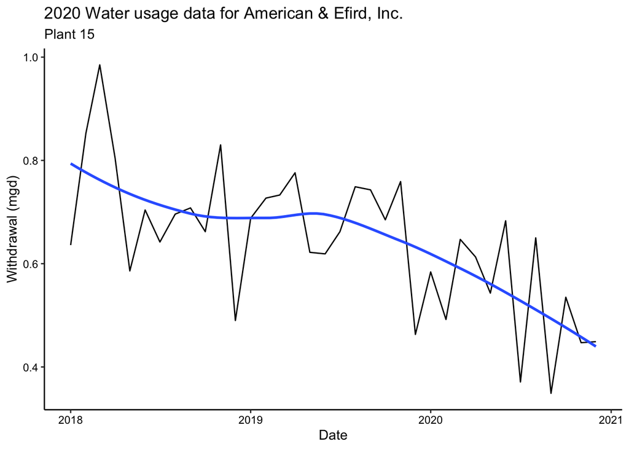

```r
#Set the inputs to scrape years 2015 to 2020 for the site "0004-0001"
the_years = rep(2018:2020) #this doesn't show up in my env either?
my_facility = '0004-0001'

#Use lapply to apply the scrape function. running it for every value in the the_years vector
the_dfs <- lapply(X = the_years,
                  FUN = scrape.it,
                  the_facility=my_facility)

#OR, use purrr's map function
the_dfs <- map(the_years,scrape.it,the_facility=my_facility)

#Conflate the returned dataframes into a single dataframe
the_df <- bind_rows(the_dfs)
#bind_rows is tidyverse version of rbind

#Plot, because it's fun and rewarding
ggplot(the_df,aes(x=Date,y=Avg_Withdrawals_mgd)) +
  geom_line() +
  geom_smooth(method="loess",se=FALSE) +
  labs(title = paste("2020 Water usage data for",the_registrant),
       subtitle = the_facility_name,
       y="Withdrawal (mgd)",
       x="Date")
```

```r
#above code for labeling is wrong - John will fix
```

# Part 3. Web Crawling

## 3.1 Get a list of facility id’s via scraping

Web crawling refers to navigating within a web site to scrape data across multiple sub-pages. In the exercise above, data are scraped from just one site. but what if we wanted to grab data from all sites? To do that, we’d need to drill into each site listed on the main page.

To do this just takes just a bit of more advanced scripting and scraping. Here we show how you can scrape multiple tags into a list and then “crawl” into each site and grab its data.

```r
#example: getting facility numbers without having to individually click on all the links for all the individual sites
#we can grab links from web pages like we grabbed datasets above
#crawling: start w web page, crawl in deeper to get links etc
#Set the web page
the_main_url <- "https://www.ncwater.org/WUDC/app/WWATR/report"

#Pull its contents into our code environment
the_main_website <- read_html(the_main_url)

#Use Selector Gadget to find the tag for all the "View Report" objects, they are all linked on main webpage
#You should find this to be "#content a"

#Then extract all the nodes associated with this and rather than extracting them. don't use html_text bc this will just print the text and not the links and their info
the_facility_ids <- the_main_website %>%
  html_nodes('#content a') %>%    #Extract a list of html nodes taged with "content a"
  html_attr("href") %>%           #Pull the "href" attribute from the node
  str_split("/") %>%              #Split the html address into substrings, separated by "/"
  map_chr(.,9)                    #Extract the 9th item in the above [the webpage for a specific site], which is the facility ID

#Have a look:
head(the_facility_ids)
```

```
## [1] "0847-0001" "0043-0001" "0004-0001" "0218-0016" "0218-0017" "0218-0018"
```

## 3.2 Scrape 2020 water usage data for all sites

We have our “scrape.it” function and our list of facility IDs. We can let the code do the work and scrape all the data for 2020. Here, to limit our demand on the DWR server, we’ll just do a subset of facilities.

We use Purrr’s `map2` function which allow us to provide two vectors of equal length as parallel inputs such that the function provided (our `scrape.it` function) is run with element 1 of each list, then element 2, and so forth. This is why we need to create a list of the one year we want that is the same length as the sample of facility ids.

This website gives a nice example of this: https://dcl-prog.stanford.edu/purrr-parallel.html

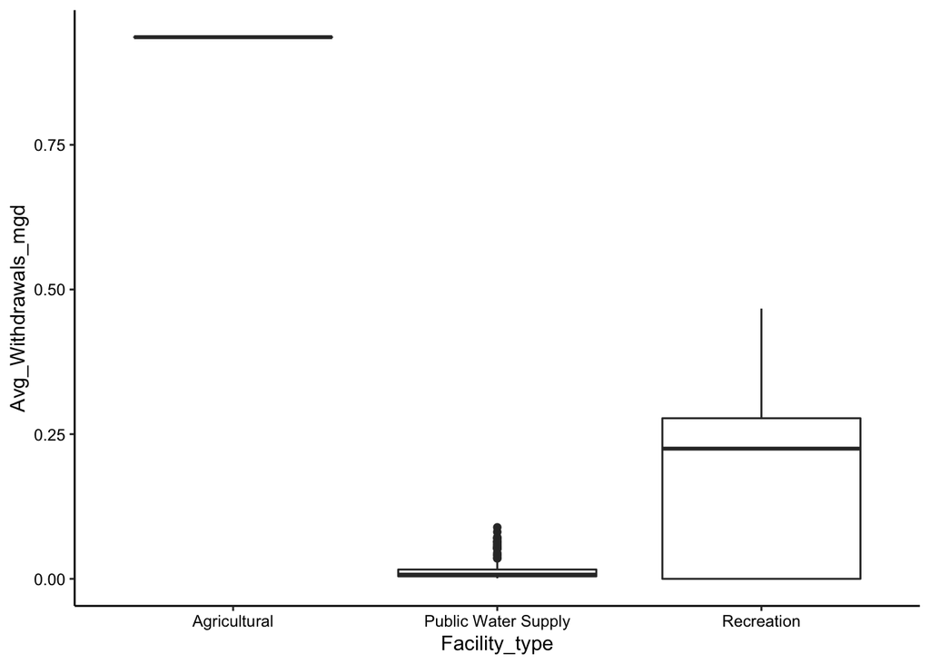

```r
#Subset the facilities: 20 at random
the_facility_ids_subset <-  sample(the_facility_ids,20)

#Create a list of the year we want, the same length as the vector above: list of years matching length of facility IDs
the_years <- rep.int(2020,length(the_facility_ids_subset))
#doing the above bc we're iterating for 2 items

#"Map" the "scrape.it" function to retrieve data for all these
dfs_2020 <- map2(the_years, the_facility_ids_subset, scrape.it)

#map2 iterates through the 2 lists in parallel: take 1st item in each pair and run that, then 2nd item in each pair and run that, etc until the last item.

#Conflate the returned list of dataframes into a single one
df_2020 <- bind_rows(dfs_2020)
#binding above list of dfs into a single df

#Plot
ggplot(df_2020,aes(y = Avg_Withdrawals_mgd, x=Facility_type)) +
  geom_boxplot()
```

## 3.3 Scraping across years and sites.

To scrape for both years and sites, we need to dig deeper into Purrr’s map functions. Most importantly we need to use the `cross2()` function to create a list of each unique combination of `year` and `facility_id.` We then use the `lift()` function to extract these elements in a way that can be easily mapped to our function.

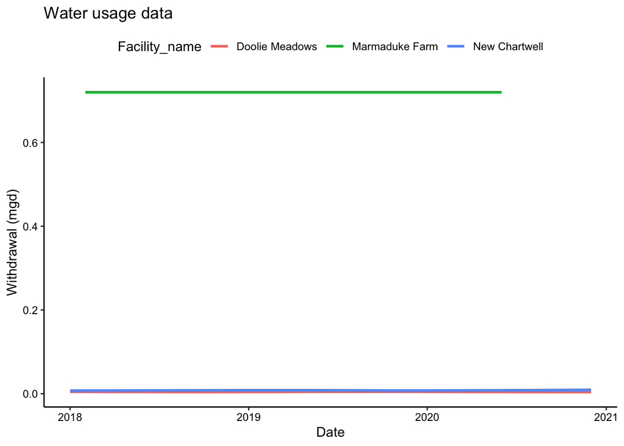

```r
#Create a subset of facilities
the_facilities <- sample(the_facility_ids,3)
the_years = c(2018,2019,2020)

#here, if we were to use map2 it would only give 2018 for site 1, 2019 for site 2, 2020 for site 3. but we want all 3 years for each site.

#Use the cross2 function to generate a list of unique combos of year and facility ids
#Then send apply our scrape.it function to grab values into a list of dataframes
the_df <- cross2(the_years,the_facilities) %>%
  map(lift(scrape.it)) %>%
  bind_rows()
#above: taking list we created and applying it into the scrape.it fxn we made, then binding things together

#Plot
ggplot(the_df,aes(x=Date,y=Avg_Withdrawals_mgd,color=Facility_name)) +
  #geom_line() +
  geom_smooth(method="loess",se=FALSE) +
  labs(title = "Water usage data",
       y="Withdrawal (mgd)",
       x="Date")
```

```r
#my graphs looked different from his bc the sites that are pulled are RANDOM. so dw about not matching video graphs.
```